# Lab 1

ED 214B

Winter 2024

## Working Directory

```r
setwd("~/Desktop/ED214_TA_Materials/ED214B/Lab1")
```

## Libraries

```r
library(readr) # importing csv file
library(psych) # describe function
library(tidyverse) # ggplot and piping operator
```

## Import Data

```r
MA_Schools <- read_csv("MA_Schools.csv")
MA_Schools
```

```
## # A tibble: 220 × 18
##     ...1    X1 district municipality expreg expsp…¹ expbil expocc exptot scratio
##    <dbl> <dbl>    <dbl> <chr>         <dbl>   <dbl>  <dbl>  <dbl>  <dbl>   <dbl>
##  1     1     1        1 Abington       4201   7376.      0      0   4646   16.6
##  2     2     2        2 Acton          4129   8574.      0      0   4930    5.70
##  3     3     3        3 Acushnet       3627   8082.      0      0   4281    7.5
##  4     4     4        5 Agawam         4015   8181.      0      0   4826    8.60
##  5     5     5        7 Amesbury       4273   7037.      0      0   4824    6.10
##  6     6     6        8 Amherst        5183  10596.   6235      0   6454    7.70
##  7     7     7        9 Andover        4685  12280.      0      0   5537    5.40
##  8     8     8       10 Arlington      5518  10055.      0      0   6405    7.10
##  9     9     9       14 Ashland        5009   8841.      0      0   5649   10.6
## 10    10    10       16 Attleboro      3823   9547.  12943  11519   4814    6.70
## # … with 210 more rows, 8 more variables: special <dbl>, lunch <dbl>,
## #   stratio <dbl>, income <dbl>, score4 <dbl>, score8 <dbl>, salary <dbl>,
## #   english <dbl>, and abbreviated variable name ¹expspecial
```

## Data Cleaning

```r
df <- MA_Schools %>%
  select(-X1) # deleting extra column X1
View(df)
```

**Is there a relationship between money allocated for schools and student performance?**

**Null hypothesis**

- $H_0$: There is no relationship between money spent and student performance
- $H_0$: $\rho$ = 0
- $H_0$: $\beta_1$ = 0

**Alternative hypothesis**

- $H_a$: There *is* a relationship between money spent and student performance
- $H_a$: $\rho \neq$ 0
- $H_a$: $\beta_1 \neq$ 0

## Inspect Variables

- Predictor: exptot (Expenditures per pupil, total)
- Outcome: score8 (8th grade score (math + English + science))

## Check the descriptives

```r
describe(df$exptot) # from psych
```

```
##    vars   n    mean     sd median trimmed    mad  min  max range skew kurtosis
## X1    1 220 5370.25 977.04   5155 5258.81 729.44 3465 9868  6403  1.3     2.51
##       se
## X1 65.87
```

```r
describe(df$score8)
```

```
##    vars   n   mean     sd median trimmed   mad  min max range  skew kurtosis
## X1    1 220 389.79 656.45    694  520.63 26.69 -999 747  1746 -1.64     0.68
##       se
## X1 44.26
```

## Graph the univariate statistics

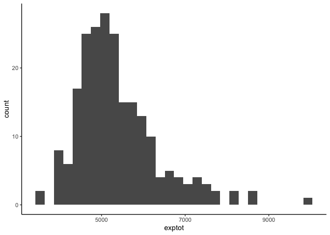

```r
df %>%
  ggplot(aes(x=exptot))+
  geom_histogram()+
  theme_classic()
```

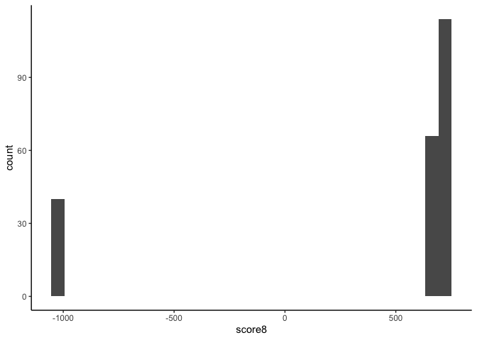

```r
df %>%
  ggplot(aes(x=score8))+
  geom_histogram()+
  theme_classic()
```

## Recode Missing Data

```r
df$score8[df$score8==-999] <- NA

sum(is.na(df$score8))
```

```
## [1] 40
```

## Check Descriptives Again

```r
describe(df$score8)
```

```
##    vars   n   mean    sd median trimmed   mad min max range skew kurtosis   se
## X1    1 180 698.41 21.05    698  698.98 19.27 641 747   106 -0.2    -0.12 1.57
```

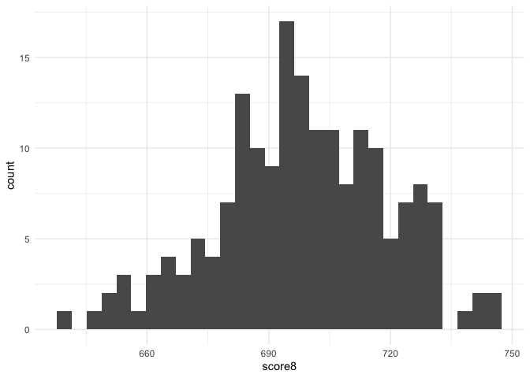

```r
df %>%
  ggplot(aes(x=score8))+
  geom_histogram()+
  theme_minimal()
```

## Plot the Relationship

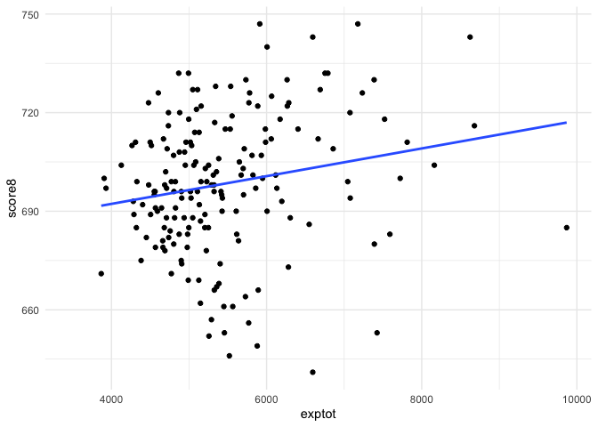

```r
df %>%
  ggplot(aes(x=exptot,y=score8))+
  geom_point()+
  theme_minimal()+
  geom_smooth(method="lm",se=FALSE)
```

## Correlation

```r
cor.test(df$exptot,df$score8)
```

```
##
##  Pearson's product-moment correlation
##
## data:  df$exptot and df$score8
## t = 2.618, df = 178, p-value = 0.009608
## alternative hypothesis: true correlation is not equal to 0
## 95 percent confidence interval:
##  0.04762991 0.32953437
## sample estimates:
##       cor
## 0.1925518
```

## Simple Linear Regression

```r
model <- lm(df$score8~df$exptot)
summary(model)
```

```
##
## Call:
## lm(formula = df$score8 ~ df$exptot)
##
## Residuals:
##     Min      1Q  Median      3Q     Max
## -62.178 -11.611   0.756  14.735  46.702
##
## Coefficients:
##              Estimate Std. Error t value Pr(>|t|)
## (Intercept) 6.754e+02  8.939e+00  75.553  < 2e-16 ***
## df$exptot   4.218e-03  1.611e-03   2.618  0.00961 **
## ---
## Signif. codes:  0 '***' 0.001 '**' 0.01 '*' 0.05 '.' 0.1 ' ' 1
##
## Residual standard error: 20.72 on 178 degrees of freedom
##   (40 observations deleted due to missingness)
## Multiple R-squared:  0.03708,    Adjusted R-squared:  0.03167
## F-statistic: 6.854 on 1 and 178 DF,  p-value: 0.009608
```

$$\hat{y} = \beta_0 +
\beta_1*x_1$$

$$\hat{y} = 675.4 +
.004218*x_1$$

A one unit increase in Expenditures per pupil is associated with a .0042 unit increase in 8th grader test scores.

$R^2$ (coefficient of determination) tells us how much the variance our model can account for. This model can account for 4% of the variance.

## Plot relationship between residuals and look at residuals

- Residuals vs Fitted: we want to see no relationship and a horizontal red line
- QQ plot: we want to see a straight line
- Scale-Location: we want to see no relationship, and a horizontal red line
- Residuals vs Leverage: used to see which residuals are influencing the regression line

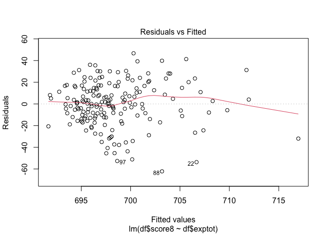

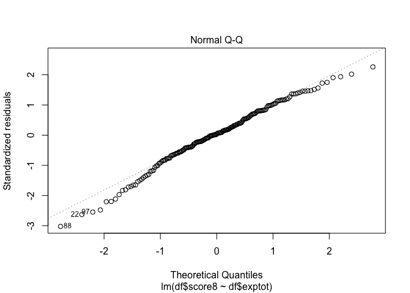

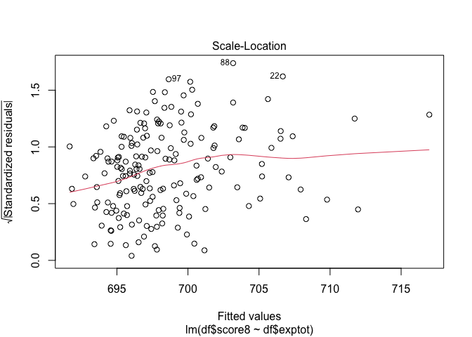

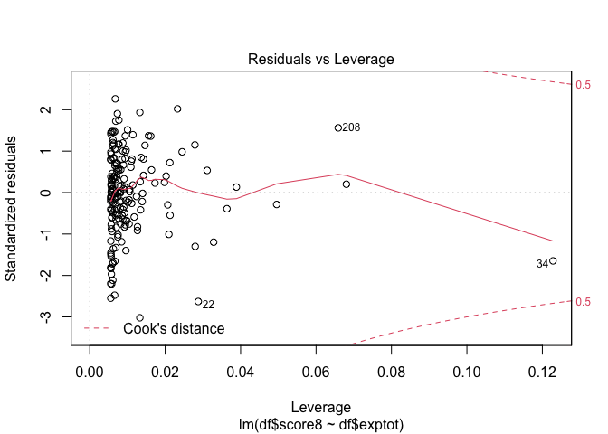

```r
plot(model)
```

## Outliers and noteworthy residuals

- Let’s look at rows 208, 22, and 34. Try practicing with row 97 on your own.
- #, = select this row

```r
df[22,]
```

```
## # A tibble: 1 × 17
##    ...1 district municipal…¹ expreg expsp…² expbil expocc exptot scratio special
##   <dbl>    <dbl> <chr>        <dbl>   <dbl>  <dbl>  <dbl>  <dbl>   <dbl>   <dbl>
## 1    22       35 Boston        5146  12417.   8856  10609   7424    7.60    21.1
## # … with 7 more variables: lunch <dbl>, stratio <dbl>, income <dbl>,
## #   score4 <dbl>, score8 <dbl>, salary <dbl>, english <dbl>, and abbreviated
## #   variable names ¹municipality, ²expspecial
```

```r
df[208,]
```

```
## # A tibble: 1 × 17
##    ...1 district municipal…¹ expreg expsp…² expbil expocc exptot scratio special
##   <dbl>    <dbl> <chr>        <dbl>   <dbl>  <dbl>  <dbl>  <dbl>   <dbl>   <dbl>
## 1   208      330 Weston        7944  10901.      0      0   8623    4.60    15.2
## # … with 7 more variables: lunch <dbl>, stratio <dbl>, income <dbl>,
## #   score4 <dbl>, score8 <dbl>, salary <dbl>, english <dbl>, and abbreviated
## #   variable names ¹municipality, ²expspecial
```

```r
df[34,]
```

```
## # A tibble: 1 × 17
##    ...1 district municipal…¹ expreg expsp…² expbil expocc exptot scratio special
##   <dbl>    <dbl> <chr>        <dbl>   <dbl>  <dbl>  <dbl>  <dbl>   <dbl>   <dbl>
## 1    34       49 Cambridge     8759  11828.   8466   7465   9868      NA    25.3
## # … with 7 more variables: lunch <dbl>, stratio <dbl>, income <dbl>,
## #   score4 <dbl>, score8 <dbl>, salary <dbl>, english <dbl>, and abbreviated
## #   variable names ¹municipality, ²expspecial
```

- Compare them to the mean, min, and max of each variable

```r
mean(df$exptot)
```

```
## [1] 5370.25
```

```r
min(df$exptot)
```

```
## [1] 3465
```

```r
max(df$exptot)
```

```
## [1] 9868
```

```r
mean(df$score8,na.rm=T)
```

```
## [1] 698.4111
```

```r
min(df$score8,na.rm=T)
```

```
## [1] 641
```

```r
max(df$score8,na.rm=T)
```

```
## [1] 747
```